# Wrangle and Analyze Data

## Goal

Since this is a real world data which rarely comes clean. My goal is to wrangle through this datasets and try creating interesting analyses and visualizations.

### DataSet Used

- [**twitter-archive-enhanced.csv**](https://viewf6b31853.udacity-student-workspaces.com/edit/twitter-archive-enhanced.csv)

Dataset contains the following columns:

1. `tweet_id`
2. `in_reply_to_status_id`
3. `in_reply_to_user_id`
4. `timestamp`
5. `source`
6. `text`
7. `retweeted_status_id`
8. `retweeted_status_user_id`
9. `retweeted_status_timestamp`
10. `expanded_urls`
11. `rating_numerator`
12. `rating_denominator`
13. `name`
14. `doggo`
15. `floofer`
16. `pupper`
17. `puppo`

--

- [**Image-predictions**](https://d17h27t6h515a5.cloudfront.net/topher/2017/August/599fd2ad_image-predictions/image-predictions.tsv) : It is a table full of image predictions along with tweet id, image URL and image number processed using neural network that classifies breeds of dogs

--

- [**Tweepy (Twitter API)**](http://docs.tweepy.org/en/latest/api.html) Tweepy is a Python library for accessing the Twitter API. It is great for simple automation and creating twitter bots.

```python
#Importing all the required libraries

import pandas as pd
import numpy as np
import matplotlib.pyplot as plt
import seaborn as sns
import requests
import tweepy
from tweepy import OAuthHandler
import json
import os
import time

%matplotlib inline
```

## Gathering Data

Importing "*image_predictions*" file using **'requests.get()'** and writing it into *"image_predictions.tsv"* after making a directory *"image_predictions"* using **'os.makedirs'**

```python
#Creating a folder for image predictions with if not condition
folder_name = 'image_predictions'
if not os.path.exists(folder_name):
    os.makedirs(folder_name)

url = 'https://d17h27t6h515a5.cloudfront.net/topher/2017/August/599fd2ad_image-predictions/image-predictions.tsv'
response = requests.get(url)
response

with open(os.path.join(folder_name,
                      url.split('/')[-1]), mode='wb') as file:
    file.write(response.content)
```

Reading **"twitter-archive-enhanced.csv"** & **"image-predictions.tsv"** imported earlier

```python
#Importing both the '.csv' as well as '.tsv' dataset into the notebook dataframe

df = pd.read_csv('twitter-archive-enhanced.csv')
image = pd.read_csv('image_predictions/image-predictions.tsv' , sep ='\t')
```

Connecting and Authorising Twitter API = "*Tweepy*" to connect to Twitter

```python
#Connecting to Twitter API and Authenticating Tweepy API

consumer_key = 'HIDDEN'
consumer_secret = 'HIDDEN'
access_token = 'HIDDEN'
access_secret = 'HIDDEN'
auth = tweepy.OAuthHandler(consumer_key, consumer_secret)
auth.set_access_token(access_token, access_secret)
```

```python
api = tweepy.API(auth_handler=auth,
                 parser=tweepy.parsers.JSONParser(),
                 wait_on_rate_limit=True,
                 wait_on_rate_limit_notify=True)
```

Collecting Tweet_id, favourite_count and retweet_count

```python
tweet_ids = list(df['tweet_id'])

tweet_data = []
tweet_id_success = []
tweet_id_missing = []
for tweet_id in tweet_ids:
    try:
        data = api.get_status(tweet_id,
                              tweet_mode='extended',
                              wait_on_rate_limit = True,
                              wait_on_rate_limit_notify = True)
        tweet_data.append(data)
        tweet_id_success.append(tweet_id)
    except:
        tweet_id_missing.append(tweet_id)
        print(tweet_id)
```

```
888202515573088257
873697596434513921
872668790621863937
872261713294495745
869988702071779329
866816280283807744
861769973181624320
856602993587888130
851953902622658560
845459076796616705
844704788403113984
842892208864923648
837366284874571778
837012587749474308
829374341691346946
827228250799742977
812747805718642688
802247111496568832
779123168116150273
775096608509886464
771004394259247104
770743923962707968
759566828574212096
Rate limit reached. Sleeping for: 732
754011816964026368
680055455951884288
Rate limit reached. Sleeping for: 735
```

```python
#For loop to append each tweet into a list
tweets_data = []

tweet_file = open('tweet_json.txt', "r")

for line in tweet_file:
    try:
        tweet = json.loads(line)
        tweets_data.append(tweet)
    except:
        continue

tweet_file.close()
```

```python
#Transposing the input after Reading it
t_df = pd.read_json('tweet_json.txt',orient='index')
t_df = t_df.T
t_df.head()
```

|  | favorites | retweets | tweet_id |
| --- | --- | --- | --- |
| 0 | 36252 | 7719 | 892420643555336193 |
| 1 | 31269 | 5706 | 892177421306343426 |
| 2 | 23543 | 3780 | 891815181378084864 |
| 3 | 39547 | 7877 | 891689557279858688 |
| 4 | 37772 | 8492 | 891327558926688256 |

## Assessing Data

Basic Information about **twitter-archive-enhanced.csv**

```python
df.info()
```

```
<class 'pandas.core.frame.DataFrame'>
RangeIndex: 2356 entries, 0 to 2355
Data columns (total 17 columns):
tweet_id                      2356 non-null int64
in_reply_to_status_id         78 non-null float64
in_reply_to_user_id           78 non-null float64
timestamp                     2356 non-null object
source                        2356 non-null object
text                          2356 non-null object
retweeted_status_id           181 non-null float64
retweeted_status_user_id      181 non-null float64
retweeted_status_timestamp    181 non-null object
expanded_urls                 2297 non-null object
rating_numerator              2356 non-null int64
rating_denominator            2356 non-null int64
name                          2356 non-null object
doggo                         2356 non-null object
floofer                       2356 non-null object
pupper                        2356 non-null object
puppo                         2356 non-null object
dtypes: float64(4), int64(3), object(10)
memory usage: 313.0+ KB
```

```python
df.head()
```

|  | tweet_id | in_reply_to_status_id | in_reply_to_user_id | timestamp | source | text | retweeted_status_id | retweeted_status_user_id | retweeted_status_timestamp | expanded_urls | rating_numerator | rating_denominator | name | doggo | floofer | pupper | puppo |
| --- | --- | --- | --- | --- | --- | --- | --- | --- | --- | --- | --- | --- | --- | --- | --- | --- | --- |
| 0 | 892420643555336193 | NaN | NaN | 2017-08-01 16:23:56 +0000 | <a href="http://twitter.com/download/iphone" r... | This is Phineas. He's a mystical boy. Only eve... | NaN | NaN | NaN | https://twitter.com/dog_rates/status/892420643... | 13 | 10 | Phineas | None | None | None | None |
| 1 | 892177421306343426 | NaN | NaN | 2017-08-01 00:17:27 +0000 | <a href="http://twitter.com/download/iphone" r... | This is Tilly. She's just checking pup on you.... | NaN | NaN | NaN | https://twitter.com/dog_rates/status/892177421... | 13 | 10 | Tilly | None | None | None | None |
| 2 | 891815181378084864 | NaN | NaN | 2017-07-31 00:18:03 +0000 | <a href="http://twitter.com/download/iphone" r... | This is Archie. He is a rare Norwegian Pouncin... | NaN | NaN | NaN | https://twitter.com/dog_rates/status/891815181... | 12 | 10 | Archie | None | None | None | None |
| 3 | 891689557279858688 | NaN | NaN | 2017-07-30 15:58:51 +0000 | <a href="http://twitter.com/download/iphone" r... | This is Darla. She commenced a snooze mid meal... | NaN | NaN | NaN | https://twitter.com/dog_rates/status/891689557... | 13 | 10 | Darla | None | None | None | None |
| 4 | 891327558926688256 | NaN | NaN | 2017-07-29 16:00:24 +0000 | <a href="http://twitter.com/download/iphone" r... | This is Franklin. He would like you to stop ca... | NaN | NaN | NaN | https://twitter.com/dog_rates/status/891327558... | 12 | 10 | Franklin | None | None | None | None |

```python
df.tail()
```

|  | tweet_id | in_reply_to_status_id | in_reply_to_user_id | timestamp | source | text | retweeted_status_id | retweeted_status_user_id | retweeted_status_timestamp | expanded_urls | rating_numerator | rating_denominator | name | doggo | floofer | pupper | puppo |
| --- | --- | --- | --- | --- | --- | --- | --- | --- | --- | --- | --- | --- | --- | --- | --- | --- | --- |
| 2351 | 666049248165822465 | NaN | NaN | 2015-11-16 00:24:50 +0000 | <a href="http://twitter.com/download/iphone" r... | Here we have a 1949 1st generation vulpix. Enj... | NaN | NaN | NaN | https://twitter.com/dog_rates/status/666049248... | 5 | 10 | None | None | None | None | None |
| 2352 | 666044226329800704 | NaN | NaN | 2015-11-16 00:04:52 +0000 | <a href="http://twitter.com/download/iphone" r... | This is a purebred Piers Morgan. Loves to Netf... | NaN | NaN | NaN | https://twitter.com/dog_rates/status/666044226... | 6 | 10 | a | None | None | None | None |
| 2353 | 666033412701032449 | NaN | NaN | 2015-11-15 23:21:54 +0000 | <a href="http://twitter.com/download/iphone" r... | Here is a very happy pup. Big fan of well-main... | NaN | NaN | NaN | https://twitter.com/dog_rates/status/666033412... | 9 | 10 | a | None | None | None | None |
| 2354 | 666029285002620928 | NaN | NaN | 2015-11-15 23:05:30 +0000 | <a href="http://twitter.com/download/iphone" r... | This is a western brown Mitsubishi terrier. Up... | NaN | NaN | NaN | https://twitter.com/dog_rates/status/666029285... | 7 | 10 | a | None | None | None | None |
| 2355 | 666020888022790149 | NaN | NaN | 2015-11-15 22:32:08 +0000 | <a href="http://twitter.com/download/iphone" r... | Here we have a Japanese Irish Setter. Lost eye... | NaN | NaN | NaN | https://twitter.com/dog_rates/status/666020888... | 8 | 10 | None | None | None | None | None |

```python
df.isnull().sum()
```

```
tweet_id                         0
in_reply_to_status_id         2278
in_reply_to_user_id           2278
timestamp                        0
source                           0
text                             0
retweeted_status_id           2175
retweeted_status_user_id      2175
retweeted_status_timestamp    2175
expanded_urls                   59
rating_numerator                 0
rating_denominator               0
name                             0
doggo                            0
floofer                          0
pupper                           0
puppo                            0
dtype: int64
```

```python
df.rating_numerator.value_counts()
```

```
12      558
11      464
10      461
13      351
9       158
8       102
7        55
14       54
5        37
6        32
3        19
4        17
1         9
2         9
420       2
```

[output cut: 26 more lines]

```python
#Entries with Numerator rating < 10
df.query('rating_numerator < 10')['rating_numerator'].count()
```

```
440
```

```python
#Entries with Denominator rating < 10
df.query('rating_denominator < 10')['rating_denominator'].count()
```

```
3
```

```python
# No of retweeted_status_id
df.retweeted_status_id.notnull().sum()
```

```
181
```

```python
#No of in_reply_to_status_id
df.in_reply_to_status_id.notnull().sum()
```

```
78
```

```python
#Different names and its count
df.name.value_counts()
```

```
None          745
a              55
Charlie        12
Cooper         11
Oliver         11
Lucy           11
Penny          10
Tucker         10
Lola           10
Bo              9
Winston         9
the             8
Sadie           8
Daisy           7
Buddy           7
an              7
Toby            7
Bailey          7
Milo            6
Stanley         6
Jax             6
Leo             6
Bella           6
Rusty           6
Koda            6
Scout           6
Oscar           6
Jack            6
Dave            6
Gus             5
             ...
Ember           1
Oddie           1
Carll           1
officially      1
Katie           1
Sobe            1
Sojourner       1
Ralphy          1
Petrick         1
Brandy          1
Smiley          1
Jerome          1
Andy            1
Duchess         1
Taz             1
Danny           1
Nida            1
Tripp           1
Shawwn          1
Florence        1
Ron             1
Hazel           1
Strider         1
Dook            1
Tuck            1
Tedrick         1
Autumn          1
Pippin          1
Kulet           1
Obi             1
Name: name, Length: 957, dtype: int64
```

```python
#Number of entries for doggo, flooper, pupper, puppo
df.doggo.value_counts() , df.floofer.value_counts() , df.pupper.value_counts() , df.puppo.value_counts()
```

```
(None     2259
 doggo      97
 Name: doggo, dtype: int64, None       2346
 floofer      10
 Name: floofer, dtype: int64, None      2099
 pupper     257
 Name: pupper, dtype: int64, None     2326
 puppo      30
 Name: puppo, dtype: int64)
```

Basic Information about **image-predictions.tsv**

```python
image.info()
```

```
<class 'pandas.core.frame.DataFrame'>
RangeIndex: 2075 entries, 0 to 2074
Data columns (total 12 columns):
tweet_id    2075 non-null int64
jpg_url     2075 non-null object
img_num     2075 non-null int64
p1          2075 non-null object
p1_conf     2075 non-null float64
p1_dog      2075 non-null bool
p2          2075 non-null object
p2_conf     2075 non-null float64
p2_dog      2075 non-null bool
p3          2075 non-null object
p3_conf     2075 non-null float64
p3_dog      2075 non-null bool
dtypes: bool(3), float64(3), int64(2), object(4)
memory usage: 152.1+ KB
```

```python
image.head()
```

|  | tweet_id | jpg_url | img_num | p1 | p1_conf | p1_dog | p2 | p2_conf | p2_dog | p3 | p3_conf | p3_dog |
| --- | --- | --- | --- | --- | --- | --- | --- | --- | --- | --- | --- | --- |
| 0 | 666020888022790149 | https://pbs.twimg.com/media/CT4udn0WwAA0aMy.jpg | 1 | Welsh_springer_spaniel | 0.465074 | True | collie | 0.156665 | True | Shetland_sheepdog | 0.061428 | True |
| 1 | 666029285002620928 | https://pbs.twimg.com/media/CT42GRgUYAA5iDo.jpg | 1 | redbone | 0.506826 | True | miniature_pinscher | 0.074192 | True | Rhodesian_ridgeback | 0.072010 | True |
| 2 | 666033412701032449 | https://pbs.twimg.com/media/CT4521TWwAEvMyu.jpg | 1 | German_shepherd | 0.596461 | True | malinois | 0.138584 | True | bloodhound | 0.116197 | True |
| 3 | 666044226329800704 | https://pbs.twimg.com/media/CT5Dr8HUEAA-lEu.jpg | 1 | Rhodesian_ridgeback | 0.408143 | True | redbone | 0.360687 | True | miniature_pinscher | 0.222752 | True |
| 4 | 666049248165822465 | https://pbs.twimg.com/media/CT5IQmsXIAAKY4A.jpg | 1 | miniature_pinscher | 0.560311 | True | Rottweiler | 0.243682 | True | Doberman | 0.154629 | True |

```python
image.tail()
```

|  | tweet_id | jpg_url | img_num | p1 | p1_conf | p1_dog | p2 | p2_conf | p2_dog | p3 | p3_conf | p3_dog |
| --- | --- | --- | --- | --- | --- | --- | --- | --- | --- | --- | --- | --- |
| 2070 | 891327558926688256 | https://pbs.twimg.com/media/DF6hr6BUMAAzZgT.jpg | 2 | basset | 0.555712 | True | English_springer | 0.225770 | True | German_short-haired_pointer | 0.175219 | True |
| 2071 | 891689557279858688 | https://pbs.twimg.com/media/DF_q7IAWsAEuuN8.jpg | 1 | paper_towel | 0.170278 | False | Labrador_retriever | 0.168086 | True | spatula | 0.040836 | False |
| 2072 | 891815181378084864 | https://pbs.twimg.com/media/DGBdLU1WsAANxJ9.jpg | 1 | Chihuahua | 0.716012 | True | malamute | 0.078253 | True | kelpie | 0.031379 | True |
| 2073 | 892177421306343426 | https://pbs.twimg.com/media/DGGmoV4XsAAUL6n.jpg | 1 | Chihuahua | 0.323581 | True | Pekinese | 0.090647 | True | papillon | 0.068957 | True |
| 2074 | 892420643555336193 | https://pbs.twimg.com/media/DGKD1-bXoAAIAUK.jpg | 1 | orange | 0.097049 | False | bagel | 0.085851 | False | banana | 0.076110 | False |

```python
image.describe()
```

|  | tweet_id | img_num | p1_conf | p2_conf | p3_conf |
| --- | --- | --- | --- | --- | --- |
| count | 2.075000e+03 | 2075.000000 | 2075.000000 | 2.075000e+03 | 2.075000e+03 |
| mean | 7.384514e+17 | 1.203855 | 0.594548 | 1.345886e-01 | 6.032417e-02 |
| std | 6.785203e+16 | 0.561875 | 0.271174 | 1.006657e-01 | 5.090593e-02 |
| min | 6.660209e+17 | 1.000000 | 0.044333 | 1.011300e-08 | 1.740170e-10 |
| 25% | 6.764835e+17 | 1.000000 | 0.364412 | 5.388625e-02 | 1.622240e-02 |
| 50% | 7.119988e+17 | 1.000000 | 0.588230 | 1.181810e-01 | 4.944380e-02 |
| 75% | 7.932034e+17 | 1.000000 | 0.843855 | 1.955655e-01 | 9.180755e-02 |
| max | 8.924206e+17 | 4.000000 | 1.000000 | 4.880140e-01 | 2.734190e-01 |

Basic Information about the JSON data from the Twitter Archive

```python
t_df.info()
```

```
<class 'pandas.core.frame.DataFrame'>
RangeIndex: 2331 entries, 0 to 2330
Data columns (total 3 columns):
favorites    2331 non-null int64
retweets     2331 non-null int64
tweet_id     2331 non-null int64
dtypes: int64(3)
memory usage: 54.7 KB
```

```python
t_df.head()
```

|  | favorites | retweets | tweet_id |
| --- | --- | --- | --- |
| 0 | 36252 | 7719 | 892420643555336193 |
| 1 | 31269 | 5706 | 892177421306343426 |
| 2 | 23543 | 3780 | 891815181378084864 |
| 3 | 39547 | 7877 | 891689557279858688 |
| 4 | 37772 | 8492 | 891327558926688256 |

```python
t_df.tail()
```

|  | favorites | retweets | tweet_id |
| --- | --- | --- | --- |
| 2326 | 96 | 39 | 666049248165822465 |
| 2327 | 272 | 132 | 666044226329800704 |
| 2328 | 112 | 41 | 666033412701032449 |
| 2329 | 121 | 42 | 666029285002620928 |
| 2330 | 2415 | 462 | 666020888022790149 |

```python
t_df.describe()
```

|  | favorites | retweets | tweet_id |
| --- | --- | --- | --- |
| count | 2331.000000 | 2331.000000 | 2.331000e+03 |
| mean | 7571.800944 | 2707.842557 | 7.419079e+17 |
| std | 11751.985941 | 4579.161022 | 6.823170e+16 |
| min | 0.000000 | 1.000000 | 6.660209e+17 |
| 25% | 1320.500000 | 548.000000 | 6.782670e+17 |
| 50% | 3292.000000 | 1269.000000 | 7.182469e+17 |
| 75% | 9268.500000 | 3146.500000 | 7.986692e+17 |
| max | 156417.000000 | 77936.000000 | 8.924206e+17 |

```python
t_df.duplicated().sum()
```

```
0
```

## Assessment - Tidiness Issues

1. Merging Datasets to one single dataset
2. Sorting Dog Stages into 1 column
3. Removing HTML Tags from Source column
4. Changing datatype of tweet_id

## Cleaning Data

```python
#Making copies of the dataframe
df_clean = df.copy()
image_clean = image.copy()
tjson_clean = t_df.copy()
```

1. Merge df_clean , image-clean, tjson_clean
2. Replace None, etc to Nan
3. Delete the unrequired columns
4. Denominator to be standardized to 10 and Numerator values less than 10 to be dropped.
5. Change timestamp to datetime standard
6. Changing column names to something appropriate

#### Define : One Master Table

Structural Issue to resolve so that only one dataframe has to be cleaned and processed

#### Code

```python
#Creating one master table :
df_clean = pd.merge(left=df,right=tjson_clean, left_on='tweet_id', right_on='tweet_id', how='inner')
```

```python
df_clean = df_clean.merge(image_clean, on='tweet_id', how='inner')
```

#### Test

```python
df_clean.info()
```

```
<class 'pandas.core.frame.DataFrame'>
Int64Index: 2059 entries, 0 to 2058
Data columns (total 30 columns):
tweet_id                      2059 non-null int64
in_reply_to_status_id         23 non-null float64
in_reply_to_user_id           23 non-null float64
timestamp                     2059 non-null object
source                        2059 non-null object
text                          2059 non-null object
retweeted_status_id           72 non-null float64
retweeted_status_user_id      72 non-null float64
retweeted_status_timestamp    72 non-null object
expanded_urls                 2059 non-null object
rating_numerator              2059 non-null int64
rating_denominator            2059 non-null int64
name                          2059 non-null object
doggo                         2059 non-null object
floofer                       2059 non-null object
pupper                        2059 non-null object
puppo                         2059 non-null object
favorites                     2059 non-null int64
retweets                      2059 non-null int64
jpg_url                       2059 non-null object
img_num                       2059 non-null int64
p1                            2059 non-null object
p1_conf                       2059 non-null float64
p1_dog                        2059 non-null bool
p2                            2059 non-null object
p2_conf                       2059 non-null float64
p2_dog                        2059 non-null bool
p3                            2059 non-null object
p3_conf                       2059 non-null float64
p3_dog                        2059 non-null bool
dtypes: bool(3), float64(7), int64(6), object(14)
memory usage: 456.4+ KB
```

#### Define : Cleaning Source column

Making the source column more readable

#### Code

```python
#Cleaning Source column using "re.findall"
import re
df_clean['source'] = df_clean['source'].apply(lambda x: re.findall(r'>(.*)<',x)[0])
```

#### Test

```python
df_clean['source'].value_counts()
```

```
Twitter for iPhone    2019
Twitter Web Client      30
TweetDeck               10
Name: source, dtype: int64
```

#### Code

```python
#Replacing improper names with np.nan
df_clean['name'] = df_clean['name'].replace(['a','an','the','None'],np.nan)
```

```python
#Removing those entries
df_clean['name'].dropna(inplace = True)
```

#### Test

```python
df_clean['name'].value_counts()
```

```
Tucker        10
Penny         10
Charlie       10
Cooper        10
Oliver        10
Lucy           9
Sadie          8
Lola           8
Winston        8
Bo             8
Toby           7
Daisy          7
Rusty          6
Stanley        6
Scout          6
Dave           6
Milo           6
Bailey         6
Jax            6
Koda           6
Bella          6
Leo            5
Oscar          5
Buddy          5
Chester        5
Larry          5
Louis          5
Alfie          5
George         4
Archie         4
              ..
Tuck           1
Tedrick        1
Autumn         1
Pippin         1
Kulet          1
Jerome         1
Smiley         1
Brandy         1
Taz            1
Duchess        1
Jordy          1
Buddah         1
Rodney         1
Erik           1
Mabel          1
Maude          1
Brandonald     1
such           1
Dotsy          1
Bobb           1
Traviss        1
Jaspers        1
Eleanor        1
Nollie         1
Shooter        1
Kollin         1
Bode           1
Swagger        1
Charleson      1
Danny          1
Name: name, Length: 930, dtype: int64
```

#### Code

```python
#Removing unrequired columns
df_clean.drop(['retweeted_status_id', 'retweeted_status_user_id', 'retweeted_status_timestamp', 'in_reply_to_status_id', 'in_reply_to_user_id' ,'expanded_urls', 'p1_dog', 'p2_dog' ,'p3_dog'], axis = 1 , inplace = True)
```

#### Test

```python
df_clean.columns
```

```
Index(['tweet_id', 'timestamp', 'source', 'text', 'rating_numerator',
       'rating_denominator', 'name', 'doggo', 'floofer', 'pupper', 'puppo',
       'favorites', 'retweets', 'jpg_url', 'img_num', 'p1', 'p1_conf', 'p2',
       'p2_conf', 'p3', 'p3_conf'],
      dtype='object')
```

```python
df_clean.head()
```

|  | tweet_id | timestamp | source | text | rating_numerator | rating_denominator | name | doggo | floofer | pupper | ... | favorites | retweets | jpg_url | img_num | p1 | p1_conf | p2 | p2_conf | p3 | p3_conf |
| --- | --- | --- | --- | --- | --- | --- | --- | --- | --- | --- | --- | --- | --- | --- | --- | --- | --- | --- | --- | --- | --- |
| 0 | 892420643555336193 | 2017-08-01 16:23:56 +0000 | Twitter for iPhone | This is Phineas. He's a mystical boy. Only eve... | 13 | 10 | Phineas | None | None | None | ... | 36252 | 7719 | https://pbs.twimg.com/media/DGKD1-bXoAAIAUK.jpg | 1 | orange | 0.097049 | bagel | 0.085851 | banana | 0.076110 |
| 1 | 892177421306343426 | 2017-08-01 00:17:27 +0000 | Twitter for iPhone | This is Tilly. She's just checking pup on you.... | 13 | 10 | Tilly | None | None | None | ... | 31269 | 5706 | https://pbs.twimg.com/media/DGGmoV4XsAAUL6n.jpg | 1 | Chihuahua | 0.323581 | Pekinese | 0.090647 | papillon | 0.068957 |
| 2 | 891815181378084864 | 2017-07-31 00:18:03 +0000 | Twitter for iPhone | This is Archie. He is a rare Norwegian Pouncin... | 12 | 10 | Archie | None | None | None | ... | 23543 | 3780 | https://pbs.twimg.com/media/DGBdLU1WsAANxJ9.jpg | 1 | Chihuahua | 0.716012 | malamute | 0.078253 | kelpie | 0.031379 |
| 3 | 891689557279858688 | 2017-07-30 15:58:51 +0000 | Twitter for iPhone | This is Darla. She commenced a snooze mid meal... | 13 | 10 | Darla | None | None | None | ... | 39547 | 7877 | https://pbs.twimg.com/media/DF_q7IAWsAEuuN8.jpg | 1 | paper_towel | 0.170278 | Labrador_retriever | 0.168086 | spatula | 0.040836 |
| 4 | 891327558926688256 | 2017-07-29 16:00:24 +0000 | Twitter for iPhone | This is Franklin. He would like you to stop ca... | 12 | 10 | Franklin | None | None | None | ... | 37772 | 8492 | https://pbs.twimg.com/media/DF6hr6BUMAAzZgT.jpg | 2 | basset | 0.555712 | English_springer | 0.225770 | German_short-haired_pointer | 0.175219 |

5 rows × 21 columns

#### Define

Changing tweet_id's data type to (string) object

#### Code

```python
df_clean['tweet_id'] = df_clean['tweet_id'].astype('str')
```

#### Test

```python
df_clean.tweet_id.dtypes
```

```
dtype('O')
```

#### Define : Removing cases with denominator is !=10

#### Code

```python
#Dropping entries with denominator not equal to 10
df_clean.drop(df_clean[df_clean.rating_denominator != 10].index,inplace = True)
```

#### Test

```python
df_clean.rating_denominator.value_counts()
```

```
10    2041
Name: rating_denominator, dtype: int64
```

#### Define : Removing cases with numerator < 10

Checking for numerator less than 10:

```python
(df_clean.rating_numerator).value_counts()
```

```
12      471
10      427
11      413
13      275
9       150
8        95
7        51
14       38
5        34
6        32
3        19
4        15
2         9
1         4
0         2
420       1
15        1
26        1
27        1
75        1
1776      1
Name: rating_numerator, dtype: int64
```

#### Code

```python
#Dropping entries with numerator less than zero
df_clean.drop(df_clean[df_clean.rating_numerator < 10].index, inplace = True)
```

#### Test

```python
(df_clean.rating_numerator).value_counts()
```

```
12      471
10      427
11      413
13      275
14       38
1776      1
420       1
75        1
27        1
26        1
15        1
Name: rating_numerator, dtype: int64
```

```python
df_clean
```

|  | tweet_id | timestamp | source | text | rating_numerator | rating_denominator | name | doggo | floofer | pupper | ... | favorites | retweets | jpg_url | img_num | p1 | p1_conf | p2 | p2_conf | p3 | p3_conf |
| --- | --- | --- | --- | --- | --- | --- | --- | --- | --- | --- | --- | --- | --- | --- | --- | --- | --- | --- | --- | --- | --- |
| 0 | 892420643555336193 | 2017-08-01 16:23:56 +0000 | Twitter for iPhone | This is Phineas. He's a mystical boy. Only eve... | 13 | 10 | Phineas | None | None | None | ... | 36252 | 7719 | https://pbs.twimg.com/media/DGKD1-bXoAAIAUK.jpg | 1 | orange | 0.097049 | bagel | 0.085851 | banana | 0.076110 |
| 1 | 892177421306343426 | 2017-08-01 00:17:27 +0000 | Twitter for iPhone | This is Tilly. She's just checking pup on you.... | 13 | 10 | Tilly | None | None | None | ... | 31269 | 5706 | https://pbs.twimg.com/media/DGGmoV4XsAAUL6n.jpg | 1 | Chihuahua | 0.323581 | Pekinese | 0.090647 | papillon | 0.068957 |
| 2 | 891815181378084864 | 2017-07-31 00:18:03 +0000 | Twitter for iPhone | This is Archie. He is a rare Norwegian Pouncin... | 12 | 10 | Archie | None | None | None | ... | 23543 | 3780 | https://pbs.twimg.com/media/DGBdLU1WsAANxJ9.jpg | 1 | Chihuahua | 0.716012 | malamute | 0.078253 | kelpie | 0.031379 |
| 3 | 891689557279858688 | 2017-07-30 15:58:51 +0000 | Twitter for iPhone | This is Darla. She commenced a snooze mid meal... | 13 | 10 | Darla | None | None | None | ... | 39547 | 7877 | https://pbs.twimg.com/media/DF_q7IAWsAEuuN8.jpg | 1 | paper_towel | 0.170278 | Labrador_retriever | 0.168086 | spatula | 0.040836 |
| 4 | 891327558926688256 | 2017-07-29 16:00:24 +0000 | Twitter for iPhone | This is Franklin. He would like you to stop ca... | 12 | 10 | Franklin | None | None | None | ... | 37772 | 8492 | https://pbs.twimg.com/media/DF6hr6BUMAAzZgT.jpg | 2 | basset | 0.555712 | English_springer | 0.225770 | German_short-haired_pointer | 0.175219 |
| 5 | 891087950875897856 | 2017-07-29 00:08:17 +0000 | Twitter for iPhone | Here we have a majestic great white breaching ... | 13 | 10 | NaN | None | None | None | ... | 19022 | 2844 | https://pbs.twimg.com/media/DF3HwyEWsAABqE6.jpg | 1 | Chesapeake_Bay_retriever | 0.425595 | Irish_terrier | 0.116317 | Indian_elephant | 0.076902 |
| 6 | 890971913173991426 | 2017-07-28 16:27:12 +0000 | Twitter for iPhone | Meet Jax. He enjoys ice cream so much he gets ... | 13 | 10 | Jax | None | None | None | ... | 11077 | 1852 | https://pbs.twimg.com/media/DF1eOmZXUAALUcq.jpg | 1 | Appenzeller | 0.341703 | Border_collie | 0.199287 | ice_lolly | 0.193548 |
| 7 | 890729181411237888 | 2017-07-28 00:22:40 +0000 | Twitter for iPhone | When you watch your owner call another dog a g... | 13 | 10 | NaN | None | None | None | ... | 61093 | 17222 | https://pbs.twimg.com/media/DFyBahAVwAAhUTd.jpg | 2 | Pomeranian | 0.566142 | Eskimo_dog | 0.178406 | Pembroke | 0.076507 |
| 8 | 890609185150312448 | 2017-07-27 16:25:51 +0000 | Twitter for iPhone | This is Zoey. She doesn't want to be one of th... | 13 | 10 | Zoey | None | None | None | ... | 26185 | 3918 | https://pbs.twimg.com/media/DFwUU__XcAEpyXI.jpg | 1 | Irish_terrier | 0.487574 | Irish_setter | 0.193054 | Chesapeake_Bay_retriever | 0.118184 |
| 9 | 890240255349198849 | 2017-07-26 15:59:51 +0000 | Twitter for iPhone | This is Cassie. She is a college pup. Studying... | 14 | 10 | Cassie | doggo | None | None | ... | 29911 | 6704 | https://pbs.twimg.com/media/DFrEyVuW0AAO3t9.jpg | 1 | Pembroke | 0.511319 | Cardigan | 0.451038 | Chihuahua | 0.029248 |
| 10 | 890006608113172480 | 2017-07-26 00:31:25 +0000 | Twitter for iPhone | This is Koda. He is a South Australian decksha... | 13 | 10 | Koda | None | None | None | ... | 28806 | 6690 | https://pbs.twimg.com/media/DFnwSY4WAAAMliS.jpg | 1 | Samoyed | 0.957979 | Pomeranian | 0.013884 | chow | 0.008167 |
| 11 | 889880896479866881 | 2017-07-25 16:11:53 +0000 | Twitter for iPhone | This is Bruno. He is a service shark. Only get... | 13 | 10 | Bruno | None | None | None | ... | 26211 | 4558 | https://pbs.twimg.com/media/DFl99B1WsAITKsg.jpg | 1 | French_bulldog | 0.377417 | Labrador_retriever | 0.151317 | muzzle | 0.082981 |
| 12 | 889665388333682689 | 2017-07-25 01:55:32 +0000 | Twitter for iPhone | Here's a puppo that seems to be on the fence a... | 13 | 10 | NaN | None | None | None | ... | 45124 | 9139 | https://pbs.twimg.com/media/DFi579UWsAAatzw.jpg | 1 | Pembroke | 0.966327 | Cardigan | 0.027356 | basenji | 0.004633 |
| 13 | 889638837579907072 | 2017-07-25 00:10:02 +0000 | Twitter for iPhone | This is Ted. He does his best. Sometimes that'... | 12 | 10 | Ted | None | None | None | ... | 25395 | 4098 | https://pbs.twimg.com/media/DFihzFfXsAYGDPR.jpg | 1 | French_bulldog | 0.991650 | boxer | 0.002129 | Staffordshire_bullterrier | 0.001498 |
| 14 | 889531135344209921 | 2017-07-24 17:02:04 +0000 | Twitter for iPhone | This is Stuart. He's sporting his favorite fan... | 13 | 10 | Stuart | None | None | None | ... | 14208 | 2059 | https://pbs.twimg.com/media/DFg_2PVW0AEHN3p.jpg | 1 | golden_retriever | 0.953442 | Labrador_retriever | 0.013834 | redbone | 0.007958 |
| 15 | 889278841981685760 | 2017-07-24 00:19:32 +0000 | Twitter for iPhone | This is Oliver. You're witnessing one of his m... | 13 | 10 | Oliver | None | None | None | ... | 23658 | 4865 | https://pbs.twimg.com/ext_tw_video_thumb/88927... | 1 | whippet | 0.626152 | borzoi | 0.194742 | Saluki | 0.027351 |
| 16 | 888917238123831296 | 2017-07-23 00:22:39 +0000 | Twitter for iPhone | This is Jim. He found a fren. Taught him how t... | 12 | 10 | Jim | None | None | None | ... | 27339 | 4111 | https://pbs.twimg.com/media/DFYRgsOUQAARGhO.jpg | 1 | golden_retriever | 0.714719 | Tibetan_mastiff | 0.120184 | Labrador_retriever | 0.105506 |
| 17 | 888804989199671297 | 2017-07-22 16:56:37 +0000 | Twitter for iPhone | This is Zeke. He has a new stick. Very proud o... | 13 | 10 | Zeke | None | None | None | ... | 24020 | 3876 | https://pbs.twimg.com/media/DFWra-3VYAA2piG.jpg | 1 | golden_retriever | 0.469760 | Labrador_retriever | 0.184172 | English_setter | 0.073482 |
| 18 | 888554962724278272 | 2017-07-22 00:23:06 +0000 | Twitter for iPhone | This is Ralphus. He's powering up. Attempting ... | 13 | 10 | Ralphus | None | None | None | ... | 18547 | 3181 | https://pbs.twimg.com/media/DFTH_O-UQAACu20.jpg | 3 | Siberian_husky | 0.700377 | Eskimo_dog | 0.166511 | malamute | 0.111411 |
| 19 | 888078434458587136 | 2017-07-20 16:49:33 +0000 | Twitter for iPhone | This is Gerald. He was just told he didn't get... | 12 | 10 | Gerald | None | None | None | ... | 20454 | 3163 | https://pbs.twimg.com/media/DFMWn56WsAAkA7B.jpg | 1 | French_bulldog | 0.995026 | pug | 0.000932 | bull_mastiff | 0.000903 |
| 20 | 887705289381826560 | 2017-07-19 16:06:48 +0000 | Twitter for iPhone | This is Jeffrey. He has a monopoly on the pool... | 13 | 10 | Jeffrey | None | None | None | ... | 28396 | 4916 | https://pbs.twimg.com/media/DFHDQBbXgAEqY7t.jpg | 1 | basset | 0.821664 | redbone | 0.087582 | Weimaraner | 0.026236 |
| 21 | 887517139158093824 | 2017-07-19 03:39:09 +0000 | Twitter for iPhone | I've yet to rate a Venezuelan Hover Wiener. Th... | 14 | 10 | such | None | None | None | ... | 43567 | 10750 | https://pbs.twimg.com/ext_tw_video_thumb/88751... | 1 | limousine | 0.130432 | tow_truck | 0.029175 | shopping_cart | 0.026321 |
| 22 | 887473957103951883 | 2017-07-19 00:47:34 +0000 | Twitter for iPhone | This is Canela. She attempted some fancy porch... | 13 | 10 | Canela | None | None | None | ... | 64580 | 16438 | https://pbs.twimg.com/media/DFDw2tyUQAAAFke.jpg | 2 | Pembroke | 0.809197 | Rhodesian_ridgeback | 0.054950 | beagle | 0.038915 |
| 23 | 887343217045368832 | 2017-07-18 16:08:03 +0000 | Twitter for iPhone | You may not have known you needed to see this ... | 13 | 10 | NaN | None | None | None | ... | 31615 | 9561 | https://pbs.twimg.com/ext_tw_video_thumb/88734... | 1 | Mexican_hairless | 0.330741 | sea_lion | 0.275645 | Weimaraner | 0.134203 |
| 24 | 887101392804085760 | 2017-07-18 00:07:08 +0000 | Twitter for iPhone | This... is a Jubilant Antarctic House Bear. We... | 12 | 10 | NaN | None | None | None | ... | 28765 | 5445 | https://pbs.twimg.com/media/DE-eAq6UwAA-jaE.jpg | 1 | Samoyed | 0.733942 | Eskimo_dog | 0.035029 | Staffordshire_bullterrier | 0.029705 |
| 25 | 886983233522544640 | 2017-07-17 16:17:36 +0000 | Twitter for iPhone | This is Maya. She's very shy. Rarely leaves he... | 13 | 10 | Maya | None | None | None | ... | 32811 | 7007 | https://pbs.twimg.com/media/DE8yicJW0AAAvBJ.jpg | 2 | Chihuahua | 0.793469 | toy_terrier | 0.143528 | can_opener | 0.032253 |
| 26 | 886736880519319552 | 2017-07-16 23:58:41 +0000 | Twitter for iPhone | This is Mingus. He's a wonderful father to his... | 13 | 10 | Mingus | None | None | None | ... | 11258 | 2936 | https://pbs.twimg.com/media/DE5Se8FXcAAJFx4.jpg | 1 | kuvasz | 0.309706 | Great_Pyrenees | 0.186136 | Dandie_Dinmont | 0.086346 |
| 27 | 886680336477933568 | 2017-07-16 20:14:00 +0000 | Twitter for iPhone | This is Derek. He's late for a dog meeting. 13... | 13 | 10 | Derek | None | None | None | ... | 21107 | 4083 | https://pbs.twimg.com/media/DE4fEDzWAAAyHMM.jpg | 1 | convertible | 0.738995 | sports_car | 0.139952 | car_wheel | 0.044173 |
| 28 | 886366144734445568 | 2017-07-15 23:25:31 +0000 | Twitter for iPhone | This is Roscoe. Another pupper fallen victim t... | 12 | 10 | Roscoe | None | None | pupper | ... | 19860 | 2892 | https://pbs.twimg.com/media/DE0BTnQUwAApKEH.jpg | 1 | French_bulldog | 0.999201 | Chihuahua | 0.000361 | Boston_bull | 0.000076 |
| 29 | 886258384151887873 | 2017-07-15 16:17:19 +0000 | Twitter for iPhone | This is Waffles. His doggles are pupside down.... | 13 | 10 | Waffles | None | None | None | ... | 26292 | 5768 | https://pbs.twimg.com/media/DEyfTG4UMAE4aE9.jpg | 1 | pug | 0.943575 | shower_cap | 0.025286 | Siamese_cat | 0.002849 |
| ... | ... | ... | ... | ... | ... | ... | ... | ... | ... | ... | ... | ... | ... | ... | ... | ... | ... | ... | ... | ... | ... |
| 1989 | 667188689915760640 | 2015-11-19 03:52:34 +0000 | Twitter for iPhone | Quite an advanced dog here. Impressively dress... | 10 | 10 | NaN | None | None | None | ... | 714 | 380 | https://pbs.twimg.com/media/CUJUk2iWUAAVtOv.jpg | 1 | vacuum | 0.335830 | swab | 0.265278 | toilet_tissue | 0.140703 |
| 1990 | 667182792070062081 | 2015-11-19 03:29:07 +0000 | Twitter for iPhone | This is Timison. He just told an awful joke bu... | 10 | 10 | Timison | None | None | None | ... | 13685 | 5858 | https://pbs.twimg.com/media/CUJPNjOWsAAZRqP.jpg | 1 | golden_retriever | 0.949892 | Irish_setter | 0.010564 | Chesapeake_Bay_retriever | 0.005821 |
| 1994 | 667171260800061440 | 2015-11-19 02:43:18 +0000 | Twitter for iPhone | Say hello to Kenneth. He likes Reese's Puffs. ... | 10 | 10 | Kenneth | None | None | None | ... | 212 | 79 | https://pbs.twimg.com/media/CUJEuRIXIAAPDLt.jpg | 1 | giant_schnauzer | 0.841265 | Lakeland_terrier | 0.052744 | Irish_water_spaniel | 0.034402 |
| 1995 | 667165590075940865 | 2015-11-19 02:20:46 +0000 | Twitter for iPhone | This is Churlie. AKA Fetty Woof. Lost eye savi... | 10 | 10 | Churlie | None | None | None | ... | 2573 | 1072 | https://pbs.twimg.com/media/CUI_kHBWsAAAef5.jpg | 1 | miniature_pinscher | 0.140173 | Rottweiler | 0.134094 | beagle | 0.081900 |
| 1996 | 667160273090932737 | 2015-11-19 01:59:39 +0000 | Twitter for iPhone | This is Bradlay. He is a Ronaldinho Matsuyama ... | 11 | 10 | Bradlay | None | None | None | ... | 248 | 60 | https://pbs.twimg.com/media/CUI6uuaW4AAvCIs.jpg | 1 | golden_retriever | 0.471351 | miniature_poodle | 0.091992 | standard_poodle | 0.087385 |
| 1997 | 667152164079423490 | 2015-11-19 01:27:25 +0000 | Twitter for iPhone | This is Pipsy. He is a fluffball. Enjoys trave... | 12 | 10 | Pipsy | None | None | None | ... | 45645 | 16082 | https://pbs.twimg.com/media/CUIzWk_UwAAfUNq.jpg | 1 | toy_poodle | 0.535411 | Pomeranian | 0.087544 | miniature_poodle | 0.062050 |
| 1998 | 667138269671505920 | 2015-11-19 00:32:12 +0000 | Twitter for iPhone | Extremely intelligent dog here. Has learned to... | 10 | 10 | NaN | None | None | None | ... | 4379 | 2079 | https://pbs.twimg.com/media/CUImtzEVAAAZNJo.jpg | 1 | West_Highland_white_terrier | 0.747713 | Samoyed | 0.243629 | toy_poodle | 0.001804 |
| 1999 | 667119796878725120 | 2015-11-18 23:18:48 +0000 | Twitter for iPhone | This is Gabe. He is a southern Baklava. Gabe h... | 10 | 10 | Gabe | None | None | None | ... | 319 | 123 | https://pbs.twimg.com/media/CUIV6F7XIAA1tAM.jpg | 1 | Pembroke | 0.741563 | Chihuahua | 0.057866 | toy_poodle | 0.039125 |
| 2001 | 667073648344346624 | 2015-11-18 20:15:26 +0000 | Twitter for iPhone | Here is Dave. He is actually just a skinny leg... | 10 | 10 | Dave | None | None | None | ... | 380 | 113 | https://pbs.twimg.com/media/CUHr8WbWEAEBPgf.jpg | 1 | Chihuahua | 0.483682 | pug | 0.092494 | Brabancon_griffon | 0.057495 |
| 2003 | 667062181243039745 | 2015-11-18 19:29:52 +0000 | Twitter for iPhone | This is Keet. He is a Floridian Amukamara. Abs... | 10 | 10 | Keet | None | None | None | ... | 210 | 49 | https://pbs.twimg.com/media/CUHhgvHUAAA4aB0.jpg | 1 | Chesapeake_Bay_retriever | 0.825678 | vizsla | 0.090998 | kelpie | 0.022956 |
| 2004 | 667044094246576128 | 2015-11-18 18:17:59 +0000 | Twitter for iPhone | 12/10 gimme now https://t.co/QZAnwgnOMB | 12 | 10 | NaN | None | None | None | ... | 176 | 47 | https://pbs.twimg.com/media/CUHREBXXAAE6A9b.jpg | 1 | golden_retriever | 0.765266 | Labrador_retriever | 0.206694 | seat_belt | 0.010667 |
| 2006 | 666996132027977728 | 2015-11-18 15:07:24 +0000 | Twitter for iPhone | This is Carll. He wants to be a donkey. But al... | 10 | 10 | Carll | None | None | None | ... | 232 | 84 | https://pbs.twimg.com/media/CUGlb6iUwAITEbW.jpg | 1 | hay | 0.507637 | Rottweiler | 0.062490 | water_buffalo | 0.048425 |
| 2007 | 666983947667116034 | 2015-11-18 14:18:59 +0000 | Twitter for iPhone | This is a curly Ticonderoga named Pepe. No fee... | 11 | 10 | NaN | None | None | None | ... | 2437 | 928 | https://pbs.twimg.com/media/CUGaXDhW4AY9JUH.jpg | 1 | swab | 0.589446 | chain_saw | 0.190142 | wig | 0.034510 |
| 2009 | 666835007768551424 | 2015-11-18 04:27:09 +0000 | Twitter for iPhone | These are Peruvian Feldspars. Their names are ... | 10 | 10 | NaN | None | None | None | ... | 200 | 77 | https://pbs.twimg.com/media/CUES51dXIAEahyG.jpg | 1 | Airedale | 0.448459 | toy_poodle | 0.124030 | teddy | 0.110183 |
| 2010 | 666826780179869698 | 2015-11-18 03:54:28 +0000 | Twitter for iPhone | 12/10 simply brilliant pup https://t.co/V6ZzG4... | 12 | 10 | NaN | None | None | None | ... | 243 | 88 | https://pbs.twimg.com/media/CUELa0NUkAAscGC.jpg | 1 | Maltese_dog | 0.359383 | teddy | 0.148759 | West_Highland_white_terrier | 0.106007 |
| 2014 | 666781792255496192 | 2015-11-18 00:55:42 +0000 | Twitter for iPhone | This is a purebred Bacardi named Octaviath. Ca... | 10 | 10 | NaN | None | None | None | ... | 367 | 179 | https://pbs.twimg.com/media/CUDigRXXIAATI_H.jpg | 1 | Italian_greyhound | 0.618316 | Weimaraner | 0.151363 | vizsla | 0.085989 |
| 2016 | 666739327293083650 | 2015-11-17 22:06:57 +0000 | Twitter for iPhone | This is Lugan. He is a Bohemian Rhapsody. Very... | 10 | 10 | Lugan | None | None | None | ... | 223 | 62 | https://pbs.twimg.com/media/CUC74aTWoAInZey.jpg | 1 | miniature_poodle | 0.546933 | cocker_spaniel | 0.165255 | toy_poodle | 0.095959 |
| 2021 | 666454714377183233 | 2015-11-17 03:16:00 +0000 | Twitter for iPhone | I'll name the dogs from now on. This is Kreggo... | 10 | 10 | Kreggory | None | None | None | ... | 491 | 199 | https://pbs.twimg.com/media/CT-5Bs-WUAA2JeC.jpg | 1 | dalmatian | 0.278954 | Labrador_retriever | 0.237612 | Great_Pyrenees | 0.171106 |
| 2024 | 666435652385423360 | 2015-11-17 02:00:15 +0000 | Twitter for iPhone | "Can you behave? You're ruining my wedding day... | 10 | 10 | NaN | None | None | None | ... | 159 | 48 | https://pbs.twimg.com/media/CT-nsTQWEAEkyDn.jpg | 1 | Chesapeake_Bay_retriever | 0.184130 | chain_saw | 0.056775 | power_drill | 0.036763 |
| 2027 | 666421158376562688 | 2015-11-17 01:02:40 +0000 | Twitter for iPhone | *internally screaming* 12/10 https://t.co/YMcr... | 12 | 10 | NaN | None | None | None | ... | 301 | 106 | https://pbs.twimg.com/media/CT-aggCXAAIMfT3.jpg | 1 | Blenheim_spaniel | 0.906777 | cocker_spaniel | 0.090346 | Shih-Tzu | 0.001117 |
| 2028 | 666418789513326592 | 2015-11-17 00:53:15 +0000 | Twitter for iPhone | This is Walter. He is an Alaskan Terrapin. Lov... | 10 | 10 | Walter | None | None | None | ... | 115 | 42 | https://pbs.twimg.com/media/CT-YWb7U8AA7QnN.jpg | 1 | toy_terrier | 0.149680 | papillon | 0.148258 | Chihuahua | 0.142860 |
| 2032 | 666373753744588802 | 2015-11-16 21:54:18 +0000 | Twitter for iPhone | Those are sunglasses and a jean jacket. 11/10 ... | 11 | 10 | NaN | None | None | None | ... | 173 | 84 | https://pbs.twimg.com/media/CT9vZEYWUAAlZ05.jpg | 1 | soft-coated_wheaten_terrier | 0.326467 | Afghan_hound | 0.259551 | briard | 0.206803 |
| 2035 | 666345417576210432 | 2015-11-16 20:01:42 +0000 | Twitter for iPhone | Look at this jokester thinking seat belt laws ... | 10 | 10 | NaN | None | None | None | ... | 274 | 128 | https://pbs.twimg.com/media/CT9Vn7PWoAA_ZCM.jpg | 1 | golden_retriever | 0.858744 | Chesapeake_Bay_retriever | 0.054787 | Labrador_retriever | 0.014241 |
| 2039 | 666273097616637952 | 2015-11-16 15:14:19 +0000 | Twitter for iPhone | Can take selfies 11/10 https://t.co/ws2AMaNwPW | 11 | 10 | NaN | None | None | None | ... | 161 | 72 | https://pbs.twimg.com/media/CT8T1mtUwAA3aqm.jpg | 1 | Italian_greyhound | 0.176053 | toy_terrier | 0.111884 | basenji | 0.111152 |
| 2040 | 666268910803644416 | 2015-11-16 14:57:41 +0000 | Twitter for iPhone | Very concerned about fellow dog trapped in com... | 10 | 10 | NaN | None | None | None | ... | 96 | 32 | https://pbs.twimg.com/media/CT8QCd1WEAADXws.jpg | 1 | desktop_computer | 0.086502 | desk | 0.085547 | bookcase | 0.079480 |
| 2042 | 666102155909144576 | 2015-11-16 03:55:04 +0000 | Twitter for iPhone | Oh my. Here you are seeing an Adobe Setter giv... | 11 | 10 | NaN | None | None | None | ... | 71 | 11 | https://pbs.twimg.com/media/CT54YGiWUAEZnoK.jpg | 1 | English_setter | 0.298617 | Newfoundland | 0.149842 | borzoi | 0.133649 |
| 2046 | 666073100786774016 | 2015-11-16 01:59:36 +0000 | Twitter for iPhone | Let's hope this flight isn't Malaysian (lol). ... | 10 | 10 | NaN | None | None | None | ... | 297 | 146 | https://pbs.twimg.com/media/CT5d9DZXAAALcwe.jpg | 1 | Walker_hound | 0.260857 | English_foxhound | 0.175382 | Ibizan_hound | 0.097471 |
| 2048 | 666063827256086533 | 2015-11-16 01:22:45 +0000 | Twitter for iPhone | This is the happiest dog you will ever see. Ve... | 10 | 10 | NaN | None | None | None | ... | 447 | 198 | https://pbs.twimg.com/media/CT5Vg_wXIAAXfnj.jpg | 1 | golden_retriever | 0.775930 | Tibetan_mastiff | 0.093718 | Labrador_retriever | 0.072427 |
| 2051 | 666055525042405380 | 2015-11-16 00:49:46 +0000 | Twitter for iPhone | Here is a Siberian heavily armored polar bear ... | 10 | 10 | NaN | None | None | None | ... | 410 | 221 | https://pbs.twimg.com/media/CT5N9tpXIAAifs1.jpg | 1 | chow | 0.692517 | Tibetan_mastiff | 0.058279 | fur_coat | 0.054449 |
| 2053 | 666050758794694657 | 2015-11-16 00:30:50 +0000 | Twitter for iPhone | This is a truly beautiful English Wilson Staff... | 10 | 10 | NaN | None | None | None | ... | 125 | 51 | https://pbs.twimg.com/media/CT5Jof1WUAEuVxN.jpg | 1 | Bernese_mountain_dog | 0.651137 | English_springer | 0.263788 | Greater_Swiss_Mountain_dog | 0.016199 |

1630 rows × 21 columns

#### Define: Timestamp to datetime format

#### Code

```python
#Coverting timestamp datatype to datetime
df_clean['timestamp'] = pd.to_datetime(df['timestamp'])
```

#### Test

```python
df_clean.info()
```

```
<class 'pandas.core.frame.DataFrame'>
Int64Index: 1630 entries, 0 to 2053
Data columns (total 21 columns):
tweet_id              1630 non-null object
timestamp             1630 non-null datetime64[ns]
source                1630 non-null object
text                  1630 non-null object
rating_numerator      1630 non-null int64
rating_denominator    1630 non-null int64
name                  1157 non-null object
doggo                 1630 non-null object
floofer               1630 non-null object
pupper                1630 non-null object
puppo                 1630 non-null object
favorites             1630 non-null int64
retweets              1630 non-null int64
jpg_url               1630 non-null object
img_num               1630 non-null int64
p1                    1630 non-null object
p1_conf               1630 non-null float64
p2                    1630 non-null object
p2_conf               1630 non-null float64
p3                    1630 non-null object
p3_conf               1630 non-null float64
dtypes: datetime64[ns](1), float64(3), int64(5), object(12)
memory usage: 280.2+ KB
```

#### Define : Renaming the columns appropriately and Dropping unrequired columns

Now since denominator is standardized dropping the column and giving rest of the column an appropriate name

#### Code

```python
#Dropping the columns which I wont be using for the analysis
drp = ['rating_denominator']
df_clean.drop(drp,inplace = True, axis = 1)
```

#### Test

```python
df_clean.columns
```

```
Index(['tweet_id', 'timestamp', 'source', 'text', 'rating_numerator', 'name',
       'doggo', 'floofer', 'pupper', 'puppo', 'favorites', 'retweets',
       'jpg_url', 'img_num', 'p1', 'p1_conf', 'p2', 'p2_conf', 'p3',
       'p3_conf'],
      dtype='object')
```

#### Code

```python
#Renaming columns
df_clean.rename(columns={'rating_numerator': 'rating_out_of_10', 'p1':'prediction1_breed' , 'p1_conf': 'p1_confidence', 'p2': 'prediction2_breed' , 'p2_conf': 'p2_confidence', 'p3': 'prediction3_breed','p3_conf':'p3_confidence' , 'retweets':'retweet_count', 'favorites':'favorite_count'}, inplace=True)
```

#### Test

```python
df_clean.columns
```

```
Index(['tweet_id', 'timestamp', 'source', 'text', 'rating_out_of_10', 'name',
       'doggo', 'floofer', 'pupper', 'puppo', 'favorite_count',
       'retweet_count', 'jpg_url', 'img_num', 'prediction1_breed',
       'p1_confidence', 'prediction2_breed', 'p2_confidence',
       'prediction3_breed', 'p3_confidence'],
      dtype='object')
```

#### Define

Create Stage_dog from doggo, floofer, pupper, puppo

#### Code

```python
df_clean = df_clean.reset_index()
del df_clean['index']
df_clean['stage_dog'] = np.nan
```

```python
#Making a single column for dog_stage using for loop

for i in range(0, len(df_clean.index)):
    if df_clean.loc[i, 'doggo'] == 'doggo':
        df_clean.loc[i, 'stage_dog'] = 'doggo'
    elif df_clean.loc[i, 'floofer'] == 'floofer':
        df_clean.loc[i, 'stage_dog'] = 'floofer'
    elif df_clean.loc[i, 'pupper'] == 'pupper':
        df_clean.loc[i, 'stage_dog'] = 'pupper'
    elif df_clean.loc[i, 'puppo'] == 'puppo':
        df_clean.loc[i, 'stage_dog'] = 'puppo'
    else:
        df_clean.loc[i, 'stage_dog'] = np.nan
```

#### Test

```python
df_clean.columns
```

```
Index(['tweet_id', 'timestamp', 'source', 'text', 'rating_out_of_10', 'name',
       'doggo', 'floofer', 'pupper', 'puppo', 'favorite_count',
       'retweet_count', 'jpg_url', 'img_num', 'prediction1_breed',
       'p1_confidence', 'prediction2_breed', 'p2_confidence',
       'prediction3_breed', 'p3_confidence', 'stage_dog'],
      dtype='object')
```

#### Define

Droppping the doggo, floofer, pupper, puppo columns as they are not required anymore

#### Code

```python
list = ['doggo', 'floofer', 'pupper', 'puppo']
df_clean = df_clean.drop(list, axis = 1)
```

#### Test

```python
df_clean.columns
```

```
Index(['tweet_id', 'timestamp', 'source', 'text', 'rating_out_of_10', 'name',
       'favorite_count', 'retweet_count', 'jpg_url', 'img_num',
       'prediction1_breed', 'p1_confidence', 'prediction2_breed',
       'p2_confidence', 'prediction3_breed', 'p3_confidence', 'stage_dog'],
      dtype='object')
```

## Exporting to .csv

#### Code

```python
df_clean.to_csv('twitter_archive_master.csv', index = False)
```

## Analyse and Visualize

```python
df_clean.info()
```

```
<class 'pandas.core.frame.DataFrame'>
RangeIndex: 1630 entries, 0 to 1629
Data columns (total 17 columns):
tweet_id             1630 non-null object
timestamp            1630 non-null datetime64[ns]
source               1630 non-null object
text                 1630 non-null object
rating_out_of_10     1630 non-null int64
name                 1157 non-null object
favorite_count       1630 non-null int64
retweet_count        1630 non-null int64
jpg_url              1630 non-null object
img_num              1630 non-null int64
prediction1_breed    1630 non-null object
p1_confidence        1630 non-null float64
prediction2_breed    1630 non-null object
p2_confidence        1630 non-null float64
prediction3_breed    1630 non-null object
p3_confidence        1630 non-null float64
stage_dog            274 non-null object
dtypes: datetime64[ns](1), float64(3), int64(4), object(9)
memory usage: 216.6+ KB
```

```python
df_clean.describe()
```

|  | rating_out_of_10 | favorite_count | retweet_count | img_num | p1_confidence | p2_confidence | p3_confidence |
| --- | --- | --- | --- | --- | --- | --- | --- |
| count | 1630.000000 | 1630.000000 | 1630.000000 | 1630.000000 | 1630.000000 | 1.630000e+03 | 1.630000e+03 |
| mean | 12.828834 | 9388.700613 | 3024.768712 | 1.246012 | 0.606676 | 1.354061e-01 | 5.995882e-02 |
| std | 44.899364 | 13065.138545 | 4942.991252 | 0.613111 | 0.267844 | 1.014260e-01 | 5.157822e-02 |
| min | 10.000000 | 0.000000 | 11.000000 | 1.000000 | 0.055379 | 1.011300e-08 | 1.740170e-10 |
| 25% | 10.000000 | 2071.750000 | 693.000000 | 1.000000 | 0.372202 | 5.271740e-02 | 1.540382e-02 |
| 50% | 11.000000 | 4751.500000 | 1621.000000 | 1.000000 | 0.606421 | 1.204195e-01 | 4.840140e-02 |
| 75% | 12.000000 | 12139.000000 | 3445.750000 | 1.000000 | 0.852390 | 1.964605e-01 | 9.276225e-02 |
| max | 1776.000000 | 156417.000000 | 77936.000000 | 4.000000 | 1.000000 | 4.676780e-01 | 2.710420e-01 |

```python
df_clean.head()
```

|  | tweet_id | timestamp | source | text | rating_out_of_10 | name | favorite_count | retweet_count | jpg_url | img_num | prediction1_breed | p1_confidence | prediction2_breed | p2_confidence | prediction3_breed | p3_confidence | stage_dog |
| --- | --- | --- | --- | --- | --- | --- | --- | --- | --- | --- | --- | --- | --- | --- | --- | --- | --- |
| 0 | 892420643555336193 | 2017-08-01 16:23:56 | Twitter for iPhone | This is Phineas. He's a mystical boy. Only eve... | 13 | Phineas | 36252 | 7719 | https://pbs.twimg.com/media/DGKD1-bXoAAIAUK.jpg | 1 | orange | 0.097049 | bagel | 0.085851 | banana | 0.076110 | NaN |
| 1 | 892177421306343426 | 2017-08-01 00:17:27 | Twitter for iPhone | This is Tilly. She's just checking pup on you.... | 13 | Tilly | 31269 | 5706 | https://pbs.twimg.com/media/DGGmoV4XsAAUL6n.jpg | 1 | Chihuahua | 0.323581 | Pekinese | 0.090647 | papillon | 0.068957 | NaN |
| 2 | 891815181378084864 | 2017-07-31 00:18:03 | Twitter for iPhone | This is Archie. He is a rare Norwegian Pouncin... | 12 | Archie | 23543 | 3780 | https://pbs.twimg.com/media/DGBdLU1WsAANxJ9.jpg | 1 | Chihuahua | 0.716012 | malamute | 0.078253 | kelpie | 0.031379 | NaN |
| 3 | 891689557279858688 | 2017-07-30 15:58:51 | Twitter for iPhone | This is Darla. She commenced a snooze mid meal... | 13 | Darla | 39547 | 7877 | https://pbs.twimg.com/media/DF_q7IAWsAEuuN8.jpg | 1 | paper_towel | 0.170278 | Labrador_retriever | 0.168086 | spatula | 0.040836 | NaN |
| 4 | 891327558926688256 | 2017-07-29 16:00:24 | Twitter for iPhone | This is Franklin. He would like you to stop ca... | 12 | Franklin | 37772 | 8492 | https://pbs.twimg.com/media/DF6hr6BUMAAzZgT.jpg | 2 | basset | 0.555712 | English_springer | 0.225770 | German_short-haired_pointer | 0.175219 | NaN |

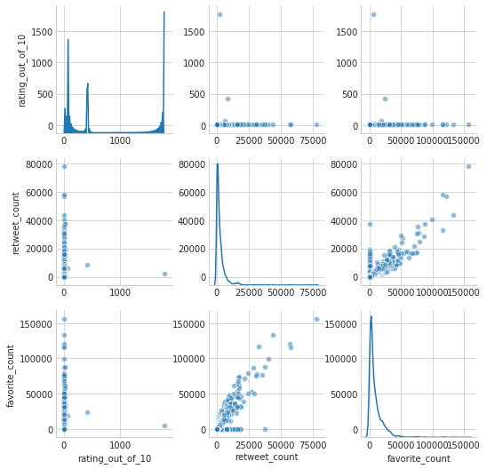

```python
sns.pairplot(df_clean,vars = ['rating_out_of_10', 'retweet_count', 'favorite_count'], diag_kind = 'kde', plot_kws = {'alpha': 0.5});
```

### What is the Most Common Dog Category ?

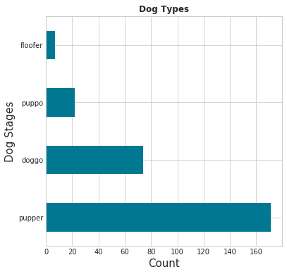

```python
#Set the aesthetic style of the plot
sns.set_style('whitegrid')
df_clean['stage_dog'].value_counts().sort_values(ascending=False).plot(kind = 'barh', figsize = (6,6), color = '#007892');
plt.title('Dog Types', weight='bold');
plt.xlabel('Count' , fontsize = 15) , plt.ylabel('Dog Stages' , fontsize = 15);
plt.savefig('Type.png')
```

### What is the Most Common Rating ?

As We can see, Most common rating to a dog is **12**

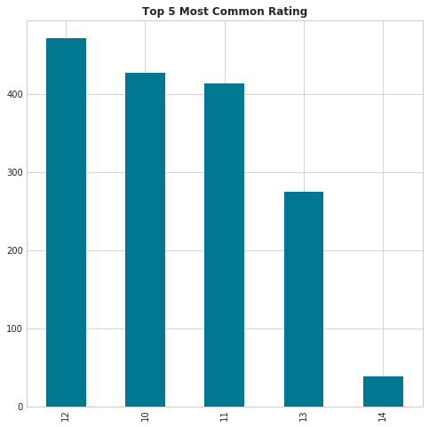

```python
#Set the aesthetic style of the plot
sns.set_style('whitegrid')
#Plotting Pie Chart
df_clean['rating_out_of_10'].value_counts()[0:5].sort_values(ascending=False).plot(kind = 'bar', figsize = (8,8) , color='#007892');
#Plot title
plt.title('Top 5 Most Common Rating', weight='bold');
plt.xlabel('') , plt.ylabel('');
plt.savefig('Rating.png')
```

### Compare between retweets and favourites based on time

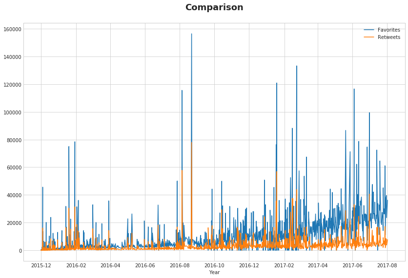

```python
#PLotting line graph
plt.subplots(figsize=(14, 9))
#Linegraph1
plt.plot(df_clean.timestamp, df_clean.favorite_count, label="Favorites")
#linegraph2
plt.plot(df_clean.timestamp, df_clean.retweet_count, label="Retweets")
#title
plt.title('Comparison\n', fontsize=18, weight='bold')
plt.xlabel('Year')
plt.legend();
plt.savefig('Yearwise.png')
```

### Any Relation between Rating and Retweets ?

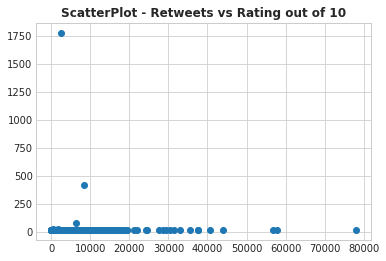

```python
#Plotting Scatter
plt.scatter( df_clean.retweet_count , df_clean.rating_out_of_10);
plt.title('ScatterPlot - Retweets vs Rating out of 10', weight='bold');
```

The scatter plot between retweets and ratings is a horizontal line meaning there is no positive or negative correlation between

### What are the most common dog names ?

[figure not shown]

```python
#Set the aesthetic style of the plot
sns.set_style('whitegrid')
#Plotting Bar Graph
df_clean['name'].value_counts()[0:20].sort_values(ascending=False).plot(kind = 'bar', figsize = (15,5));
plt.title('15 Most Common Names of Dogs', weight='bold');
plt.xlabel('Names of Dogs' , fontsize = 15) , plt.ylabel('Count' , fontsize = 15);
plt.savefig('TopName.png')
```

### What is the preferred interface for tweeting ?

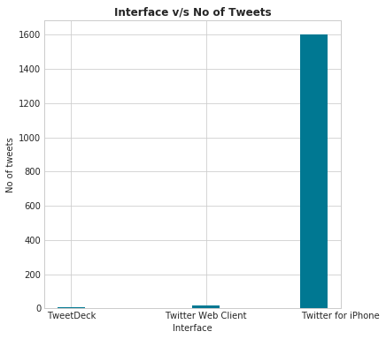

```python
#Set the aesthetic style of the plot
sns.set_style('whitegrid');
plt.figure(figsize = (6,6));
#Plotting Histogram
plt.hist(df_clean['source'],align = 'left' , color = '#007892');
plt.xlabel('Interface');
plt.ylabel('No of tweets');
plt.title('Interface v/s No of Tweets' , weight='bold');
plt.savefig('Interface.png')
```

```python
print('% of Tweets made using iPhone',(df_clean.query('source == "Twitter for iPhone"')['source'].count() / df_clean.source.count())*100)
```

```
% of Tweets made using iPhone 98.3435582822
```

### Show Correlations

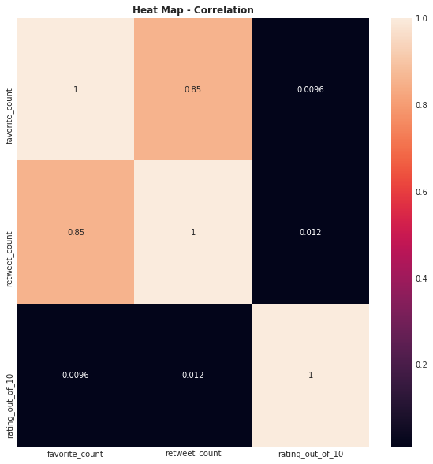

```python
#Plotting Heatmap
f,ax = plt.subplots(figsize=(10, 10));
sns.heatmap(df_clean[['favorite_count','retweet_count','rating_out_of_10']].corr(), annot=True,ax=ax)
plt.title('Heat Map - Correlation', weight = 'bold');
plt.savefig('HeatMap.png')
```

[figure not shown]

```python
#Set the aesthetic style of the plot
sns.set_style('whitegrid')
plot_fav_ret = sns.jointplot(x="favorite_count", y="retweet_count", data=df_clean, color="green", kind="reg", size=10)
plot_fav_ret.plot_joint(plt.scatter, c="#007892", s=50, alpha=0.8)
plot_fav_ret.set_axis_labels("Retweet", "Favorite",fontsize=10)
plt.suptitle('ReTweets & Favorites ScatterPlot', fontsize=12, weight='bold');
plt.savefig('Retweets_vs_Favorites.png')
```

As we can find, there is **Positive Correlation** between *Retweets and Favorites*

## Conclusion

### Limitations:

A lot of information from the data has been left out of the analysis or removed. Alot more analysis could be done on the prediction confidence as well as the breed names also this analysis may not be totally accurate based on the fact that alot of a data was been fiddled with.

### References

1. Renaming Columns - https://stackoverflow.com/questions/11346283/renaming-columns-in-pandas
2. Scatter Plot with marginal ticks - https://seaborn.pydata.org/examples/marginal_ticks.html
3. Reading JSON - https://knowledge.udacity.com/questions/66949#66975
4. re.findall - https://www.geeksforgeeks.org/python-regex-re-search-vs-re-findall/
5. plot_joint - https://seaborn.pydata.org/generated/seaborn.JointGrid.plot_joint.html
6. Seaborn Plot - https://jakevdp.github.io/PythonDataScienceHandbook/04.14-visualization-with-seaborn.html
7. Using conditions to generate new column - https://code.i-harness.com/en/q/19c9fbc

```python
from subprocess import call
call(['python', '-m', 'nbconvert', 'wrangle_act.ipynb'])
```

```
0
```